PY6301 · Session 1 · 12 November 2026

# Brain Detective

Three cases. One team quiz.

[Open BrainFacts 3D Brain ↗](https://www.brainfacts.org/3d-brain)

## How to play

The case names are fictional.

Use one device per team. Start with Round 1. After submitting, review the answers and check the scores with the class. When your instructor says to continue, open Round 2. Follow the same steps for Round 3.

### Connect to the class game

**Game link and code**

Game code

Game link

### Your team

Choose your team

Choose your assigned team.

**No team selected**0 / 17 points

0 of 3 rounds submitted

Practice only. Answers and scores are saved; notes stay on this device. Use the same browser to rejoin.

Round 1 · 6 possible points

## The Missing Left Side

**Spatial attention**

**Daniel**  
After a right-sided stroke, Daniel began leaving the left side of his paintings blank. He could still see to his left on a visual-field test. His scan showed damage to the right insula and putamen. Later, he painted across the canvas, but the two sides still differed.

**Clue:** Find the lateral sulcus on slides 6–7 and P (putamen) in the legend on slide 8.

Slides and diagrams · Round 1

1. AttentionWhat best explains Daniel’s left-sided omissions given his visual-field test?Which explanation fits the side of Daniel’s injury? (Slide 29)

2. Scan findingsWhere are the insula and putamen, and what kind of tissue is each? (Slides 6–8)How can this injury affect attention if other attention regions are intact?

3. RecoveryWhich cortical regions help direct attention while scanning the canvas? (Slides 29 and 36)What do the later paintings tell you about Daniel’s recovery?

Notes (optional)

## Resources · Round 1

Slides 6–8, 29–30, 34 and 36 (PDF pp. 6–8, 23–24, 28 and 30).

[BrainFacts 3D Brain ↗](https://www.brainfacts.org/3d-brain)

**Cortical landmarks and basal ganglia**

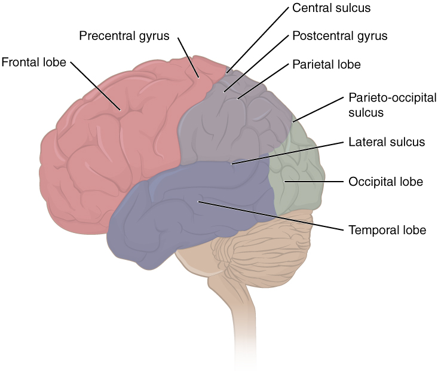

OpenStax A&P 2e, Fig. 13.7.

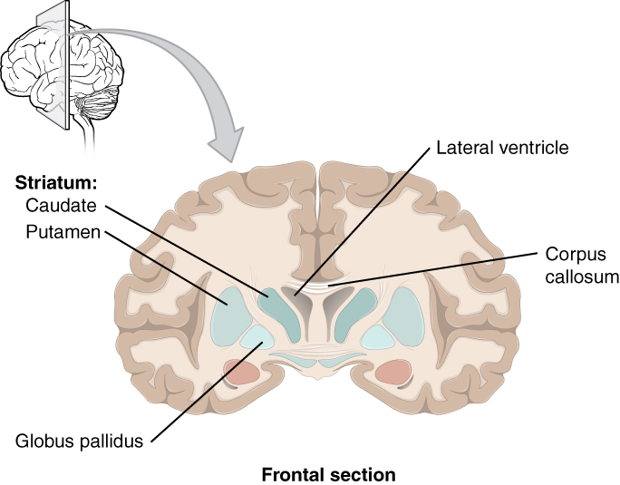

OpenStax A&P 2e, Fig. 13.9.

**Cranial nerves (optional)**

CN II carries visual input. CN III supplies most eye muscles, elevates the upper eyelid and carries pupil-constricting parasympathetic fibres. CN IV supplies superior oblique; CN VI supplies lateral rectus.

CN III motor neurons and the preganglionic Edinger–Westphal parasympathetic neurons lie in the midbrain. Trace parasympathetic fibres through CN III → ciliary ganglion → short ciliary nerves → sphincter pupillae. CN III runs near the posterior communicating artery.

[Illustrated cranial nerve anatomy reference ↗](https://www.ncbi.nlm.nih.gov/books/NBK608599/) · [Ciliary ganglion and pupil pathway ↗](https://www.ncbi.nlm.nih.gov/books/NBK553182/)

## Class scores

### Round 1 leaderboard

### Round 2 leaderboard

### Round 3 leaderboard

### Case scores

| Team | Round 1 | Round 2 | Round 3 | Total | Rounds completed |
| --- | --- | --- | --- | --- | --- |

Connecting to the class game…

**Instructor: start another class game**

Share the new link with all four teams. Previous scores stay in the original game.

## Overall leaders

Three clinical rounds (17 points) + team quiz (8 points) = 25 possible points.

| Rank | Team | Clinical rounds | Quiz | Total | Progress |
| --- | --- | --- | --- | --- | --- |

Connecting to the overall leaderboard…

## Wrap-up

For each case: what changed, where was the injury, and how might the anatomy explain the finding?

Team notes (optional)

**Blood supply and stroke (optional)**

Unscored practice · Slides 13–16 and 30.

### Stroke example: connect the lesion, function and blood supply

A scan shows an infarct in the right primary visual cortex around the calcarine sulcus. Which combination best fits this lesion?

Choose the visual-field effect and broad arterial territory

| Distribution | Anatomical context | Reasoning implication |
| --- | --- | --- |
| ACA | Mainly medial frontal and parietal | Consider leg representation and initiation systems |
| MCA | Much lateral cortex and deep branches | Language, attention and motor effects depend on side and branch |
| PCA | Much occipital and inferomedial temporal tissue; deep branches | Visual and memory effects depend on involved structures |
| Perforators | Deep nuclei and white matter | A strategic lesion may disrupt a large network |
| Border zones | Between major territories | Consider perfusion and lesion distribution |

**Arterial routes, collateral links and venous drainage**

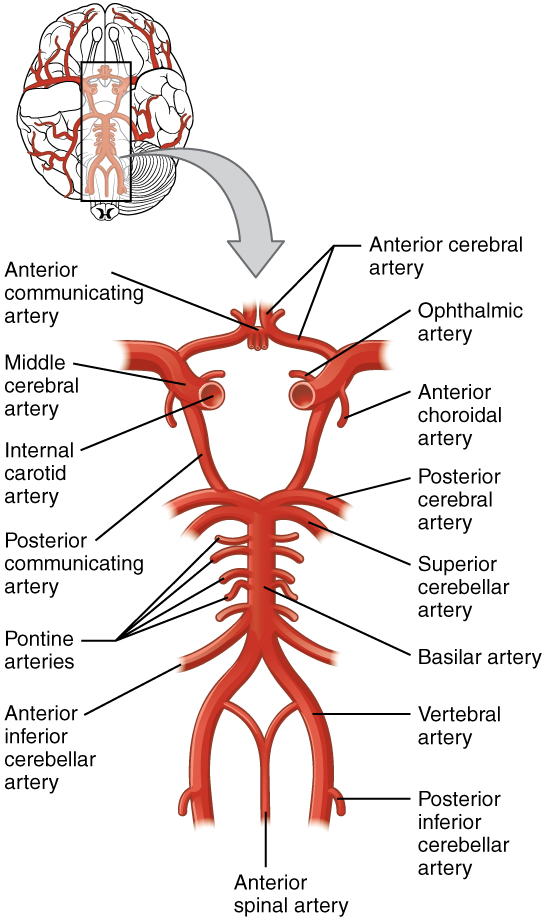

OpenStax A&P 2e, Fig. 13.15. This shows vessels, not full perfusion-territory borders.

Internal carotids give rise to ACA and MCA. Vertebral arteries unite as basilar, which usually ends in PCAs. Communicating arteries provide potential collateral routes, with anatomical variation. The MCA is not a segment of the circle of Willis. Veins drain through dural sinuses towards internal jugular veins, following a different organisation from arterial territories.

[BrainFacts stroke primer ↗](https://www.brainfacts.org/diseases-and-disorders/injury/2023/stroke)

## Sources and credits

Filley & Bigler (2017), Neuroanatomy for the Neuropsychologist, Morgan & Ricker, 2nd ed., Ch. 6, pp. 62–90. [Chapter record](https://doi.org/10.4324/9781315271743-6). Additional sources: [Ferguson et al. (2019), memory circuit](https://doi.org/10.1038/s41467-019-11353-z) and [Corbetta & Shulman (2011), spatial neglect and attention networks](https://doi.org/10.1146/annurev-neuro-061010-113731).

Figures from [OpenStax A&P 2e 13.2](https://openstax.org/books/anatomy-and-physiology-2e/pages/13-2-the-central-nervous-system), [13.3](https://openstax.org/books/anatomy-and-physiology-2e/pages/13-3-circulation-and-the-central-nervous-system), CC BY-NC-SA 4.0.